# Visualização de Dados com ggplot2

Marcus Nunes

17 e 18 de Maio de 2018

# Introdução

## Introdução

- `ggplot2` é um pacote de visualização de dados
- Foi criado por Hadley Wickham em 2007, baseado no livro *Grammar of Graphics*, de Leland Wilkinson
- A ideia principal é criar gráficos como se eles fossem frases de uma língua, onde cada elemento do gráfico é uma palavra

## Introdução

- Isto nos permite construir gráficos tão complexos quanto quisermos
- Os gráficos criados com esta ferramenta são, em geral, mais bonitos do que os gráficos tradicionais do R
- Entretanto, esta versatilidade tem dois custos associados:
  - A curva de aprendizagem do `ggplot2` é maior do que das funções gráficas tradicionais do `R` (por exemplo, `plot`, `boxplot` e `hist`)
  - É uma ferramenta mais lenta para exibir os resultados dos gráficos criados

## Introdução

- Por exemplo, veja o gráfico do próximo slide
- Este gráfico foi criado com muito pouco código utilizando `ggplot2`
- Como seria possível criá-lo utilizando as ferramentas tradicionais do `R`?

## Introdução

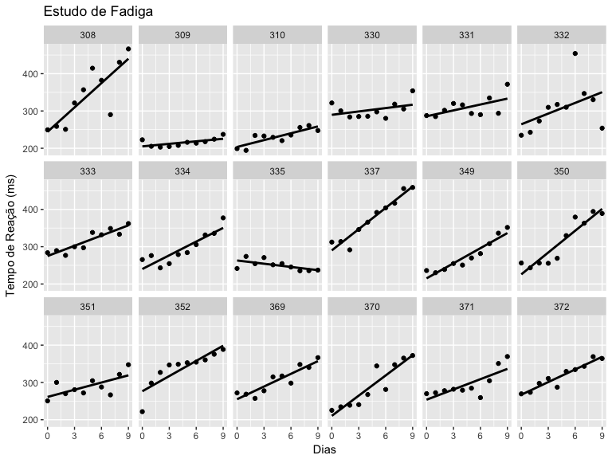

```r
ggplot(sleepstudy, aes(x=Days, y=Reaction)) +
  geom_point() +
  scale_x_continuous(breaks=seq(0, 9, 3)) +
  labs(x="Dias", y="Tempo de Reação (ms)", title="Estudo de Fadiga") +
  geom_smooth(method="lm", se=FALSE, color="black") +
  facet_wrap(~ Subject, nrow=3)
```

# Sintaxe Básica

## Sintaxe Básica

- O `ggplot2` exige que os dados a serem plotados estejam em um data frame
- Não é possível plotar diretamente os dados presentes em uma matriz ou um vetor
- **Sempre** teremos que transformar os dados para data frame ou construir um data frame com os dados que possuímos

## Sintaxe Básica

- Trabalharemos com o conjunto de dados `sleepstudy`

## Sintaxe Básica

- Verifique se está tudo correto através dos comandos

```r
str(sleepstudy)
```

```
#> Classes 'tbl_df', 'tbl' and 'data.frame':    180 obs. of  3 variables:
#>  $ Reaction: num  250 259 251 321 357 ...
#>  $ Days    : num  0 1 2 3 4 5 6 7 8 9 ...
#>  $ Subject : Factor w/ 18 levels "308","309","310",..: 1 1 1 1 1 1 1 1 1 1 ...
```

```r
head(sleepstudy)
```

```
#> # A tibble: 6 x 3
#>   Reaction  Days Subject
#>      <dbl> <dbl> <fct>
#> 1     250.    0. 308
#> 2     259.    1. 308
#> 3     251.    2. 308
#> 4     321.    3. 308
#> 5     357.    4. 308
#> 6     415.    5. 308
```

## Sintaxe Básica

- Este conjunto de dados reporta o tempo médio de reação (`Reaction`) de 18 voluntários após um certo número de dias (`Days`) em que eles dormiram 3 horas por noite
- Queremos fazer a análise exploratória deste conjunto de dados
- O objetivo ao final é que consigamos entender como construir o gráfico que vimos alguns slides atrás

## Sintaxe Básica - Gráfico de Dispersão

- O comando principal a ser utilizado se chama `ggplot`
- Através dele vamos definir qual é a variável preditora e qual é a variável resposta em nosso conjunto de dados

O comando básico a partir do qual vamos gerar todos os gráficos é

```r
ggplot(dados, aes(x=Preditora, y=Resposta))
```

## Sintaxe Básica - Gráfico de Dispersão

```r
ggplot(sleepstudy, aes(x=Days, y=Reaction))
```

[output not shown]